# Safegraph Sampling Bias

Neel Kasmalkar

April 29, 2020

This is code to test the sampling bias of Safegraph.

We first set the filepaths to various datasets

```r
# SET your path here to the covid19analysis folder.
sg_path <- '~/pCloud Drive/SFBI/Restricted Data Library/Safegraph/covid19analysis/'

#Path to a panel summary.
home_panel_M0319 <- paste0(sg_path,'historicpatterns/Mar19-AllPatterns-PATTERNS-2019_03-2020-03-23/home_panel_summary.rds')

acs_year = 2018

acs_var <- load_variables(acs_year, 'acs5', cache = T)
```

## Datasets

We now load the various datasets.

The first dataset is a Safegraph monthly panel summary for March 2019. It shows the number of devices residing in each blockgroup during that month.

The second dataset is the Census compilation of the 2018 population by blockgroup in California.

```r
panel <- readRDS(home_panel_M0319) %>%
        filter(state == 'ca')


bg_pop <- get_acs(geography = "block group", variables = "B01003_001", year = acs_year, state = 'CA') %>%
  as.data.frame() %>%
  rename(geoid = GEOID, pop = estimate) %>%
  dplyr::select(-c(variable, moe)) %>%
  filter(pop > 0)
```

## Comparison across different FIPS scales

Our approach to Safegraph normalization is that, when we see a device originating from a given region, we calculate the ratio of the population of that region to the number of devices residing in that region, and then use this multiplier to get the actual number of visitors from that region.

But how small should the region be? Should we consider blockgroups (the smallest possible)? Or the whole Bay Area? Or something in between?

*The key criterion we will use is that, once we partition our geography into regions, each region must have roughly the same ratio of regional Census population to Safegraph number of residing devices.*

Each blockgroup has a 12-digit FIPS code. The first 2 digits indicate state, The first 5 indicate county, and the first 11 indicate census tract. These 12 digits offer a way for us to control spatial normalization.

For example, we could consider regions defined by 8 digits (aggregating all blockgroups with the same first 8 digits), and use that as our region for normalization.

First, we write a function for shortening a FIPS code.

```r
#Function to trim a FIPS code.
#param x: str. A string with at least 12 characters.
#param region: char or int. If int, it will provide the first <region> characters of x.
#              If char, there are present values for obtaining county, tract and bg (blockgroup) FIPS codes.
# return str. Substring of x.
getRegionFIPSFromBG <- function(x, region = 5) {
  if (region == 'bg') return(x)
  if (region == 'county') return(substring(x,1,5))
  if (region == 'tract') return(substring(x,1,11))
  if (is.numeric(region)) return(substring(x,1,region))
}
```

## County scale

First we aggregate at the county level (first 5 digits). We then plot the counties by the Census and safegraph counts. We draw a blue line which represents the linear reation for the whole California region (*this is not a regression line*). The red line is the regression line with zero intercept, based on the individual regions.

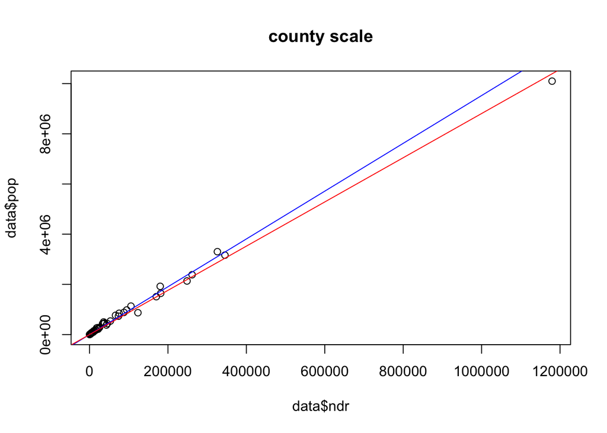

```r
scale = 'county'

#Decide spatial resolution as first 8 digits.
res = 5

#Aggregate blockgroup census data to specified region.
res_pop <- bg_pop %>%
          mutate(geoid_res = getRegionFIPSFromBG(geoid, res)) %>%
          group_by(geoid_res) %>%
          summarize(pop = sum(pop))

#Aggregate blockgroup safegraph data to specified region.
res_panel <- panel %>%
          mutate(geoid_res = getRegionFIPSFromBG(census_block_group, res)) %>%
          group_by(geoid_res) %>%
          summarize(ndr = sum(number_devices_residing))

#Merge data, compute bias with the denominator as the whole region of California.
data <- res_pop %>%
        merge(res_panel, by = 'geoid_res') %>%
        mutate(bias = (pop/ndr - sum(pop)/sum(ndr)))

#Plot the data
l = lsfit(data$ndr, data$pop, intercept = F)
plot(data$ndr, data$pop, main = paste(scale, 'scale'))
abline(a = 0.0, b = sum(data$pop)/sum(data$ndr), col= 'blue')
abline(l, col = 'red')
```

```r
angle = atan(l$coefficients) - atan(sum(data$pop)/sum(data$ndr))
print(paste('The angle between the blue and red lines is', angle))
```

```
## [1] "The angle between the blue and red lines is -0.00843740739891885"
```

## Tract scale

We now do the same exercise for the tract scale. We will see that the results are much poorer, where the statewide slope, shown as a blue line, is significantly different from the non-intercept regression line, shown in red. And you can only imagine (or actually try it out by setting res = 12), that for the block group it is even worse.

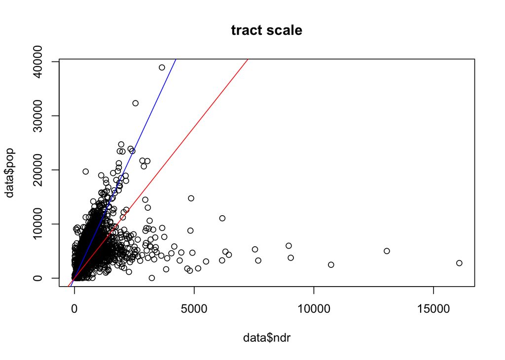

```r
scale = 'tract'

#Decide spatial resolution as first 11 digits.
res = 11

#Aggregate blockgroup census data to specified region.
res_pop <- bg_pop %>%
          mutate(geoid_res = getRegionFIPSFromBG(geoid, res)) %>%
          group_by(geoid_res) %>%
          summarize(pop = sum(pop))

#Aggregate blockgroup safegraph data to specified region.
res_panel <- panel %>%
          mutate(geoid_res = getRegionFIPSFromBG(census_block_group, res)) %>%
          group_by(geoid_res) %>%
          summarize(ndr = sum(number_devices_residing))

#Merge data, compute bias with the denominator as the whole region of California.
data <- res_pop %>%
        merge(res_panel, by = 'geoid_res') %>%
        mutate(bias = (pop/ndr - sum(pop)/sum(ndr)))

#Plot the data
l = lsfit(data$ndr, data$pop, intercept = F)
plot(data$ndr, data$pop, main = paste(scale, 'scale'))
abline(a = 0.0, b = sum(data$pop)/sum(data$ndr), col= 'blue')
abline(l, col = 'red')
```

```r
angle = atan(l$coefficients) - atan(sum(data$pop)/sum(data$ndr))
print(paste('The angle between the blue and red lines is', angle))
```

```
## [1] "The angle between the blue and red lines is -0.0729138354411614"
```

As you can see, even though the population seems well-sampled at the county level, the sampling at the tract-level is highly erratic. Safegraph mentions in its [sampling bias notebook](https://colab.research.google.com/drive/1u15afRytJMsizySFqA2EPlXSh3KTmNTQ#sandboxMode=true) that there are blockgroup sinks that are overrepresent home census blockgroups, where perhaps the devices recorded in thses blockgroups belong to residents of neighboring blockgroups. Given theses errors at small-scale resolutions, we try somewhat larger resolutions to see if we can get a nice tradeoff between regional differences and low bias.

The scale at fips8 (8 digits) seems like a good tradeoff.

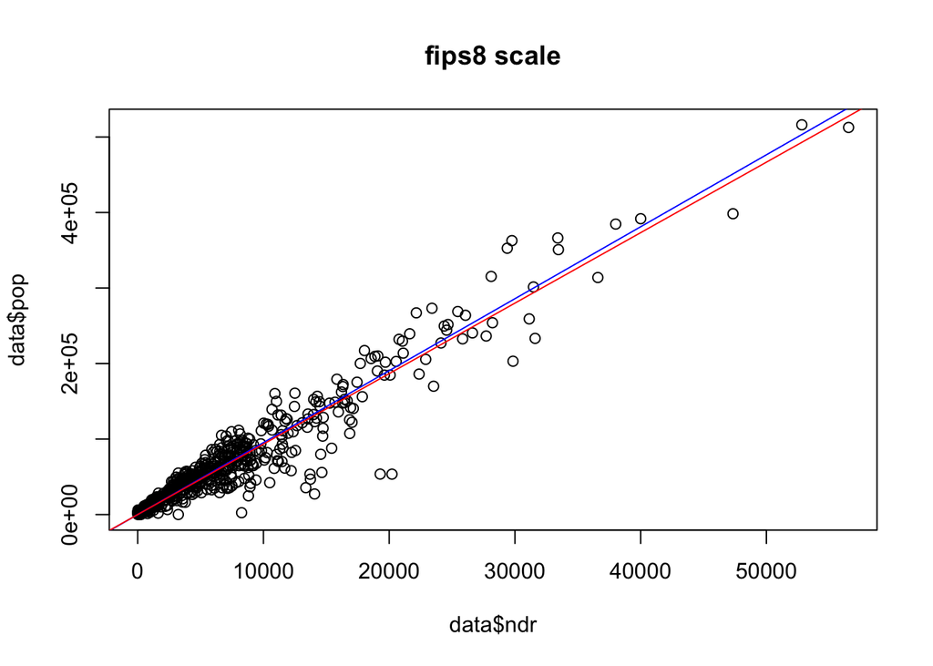

```r
scale = 'fips8'

#Decide spatial resolution as first 8 digits.
res = 8

#Aggregate blockgroup census data to specified region.
res_pop <- bg_pop %>%
          mutate(geoid_res = getRegionFIPSFromBG(geoid, res)) %>%
          group_by(geoid_res) %>%
          summarize(pop = sum(pop))

#Aggregate blockgroup safegraph data to specified region.
res_panel <- panel %>%
          mutate(geoid_res = getRegionFIPSFromBG(census_block_group, res)) %>%
          group_by(geoid_res) %>%
          summarize(ndr = sum(number_devices_residing))

#Merge data, compute bias with the denominator as the whole region of California.
data <- res_pop %>%
        merge(res_panel, by = 'geoid_res') %>%
        mutate(bias = (pop/ndr - sum(pop)/sum(ndr)))

#Plot the data
l = lsfit(data$ndr, data$pop, intercept = F)
plot(data$ndr, data$pop, main = paste(scale, 'scale'))
abline(a = 0.0, b = sum(data$pop)/sum(data$ndr), col= 'blue')
abline(l, col = 'red')
```

```r
angle = atan(l$coefficients) - atan(sum(data$pop)/sum(data$ndr))
print(paste('The angle between the blue and red lines is', angle))
```

```
## [1] "The angle between the blue and red lines is -0.0021879998745209"
```

## Conclusion for geography - use fips8

I propose that we use normalization at the fips8 level for safegraph data. This should reduce errors at the the blockgroup level, and still maintain regional variation.